# Mundial de natación de Kazán 2015

### Modelo de regresión lineal: reactiontime vs swimtime

```r
# Esto no funciona porque las dos variables continuas tienen distinto tamaño
# Hay que gestionar los NAs previamente
# Además, como solo se está trabajando con dos variables continuas, no tiene sentido hacer pairs
# Realmente es un único plot
# pairs(nadadoresPruebas$points,splitswimtime)
```

```r
nadadoresPruebas50crol<- nadadoresPruebas[nadadoresPruebas$distance==50 & nadadoresPruebas$stroke=='FREE', ]
t= nadadoresPruebas50crol$swimtime
p= nadadoresPruebas50crol$points
cor(t,p)
```

```
## [1] NA
```

```r
#verlo pero
```

Esto no es de mucho estudio, ya que es lo lógico.

Veamos los puntos respecto al tiempo de reacción:

```r
nadadoresPruebas<- na.omit(nadadoresPruebas)
x= nadadoresPruebas$points
y=nadadoresPruebas$reactiontime
```

```r
cor(x,y)
```

```
## [1] -0.2861291
```

Parecen no estar correlacionadas el tiempo de reaccion y los puntos de manera lineal. Pero a lo mejor, en pruebas específicas , como las pruebas de distancias cortas la correlación es mayor.

```r
nadadoresPruebas50<- nadadoresPruebas[nadadoresPruebas$distance==50, ]
X=nadadoresPruebas50$reactiontime
Y=nadadoresPruebas50$points
cor(X,Y)
```

```
## [1] -0.5573374
```

Ya tenemos nuestro objetivo de estudio ya que para comenzar con la modelización estadística, debemos contextualizar el problema, definiendo objetivos y variables.

Queremos investigar si existe relación entre el tiempo de reacción y puntos. Una pregunta que puede surgirnos es, ¿A mayores valores del tiempo de reacción, hay mayores valores de puntos? Luego, nuestro objetivo será saber si hay algún tipo de relación lineal, y las variables, por ende, serán tiempo de reacción y puntos. La variable tiempo de reacción, será nuestra variable independiente, y puntos será la variable dependiente.

A continuación, procedemos a realizar una inspección gráfica simple, para identificar tendencias.

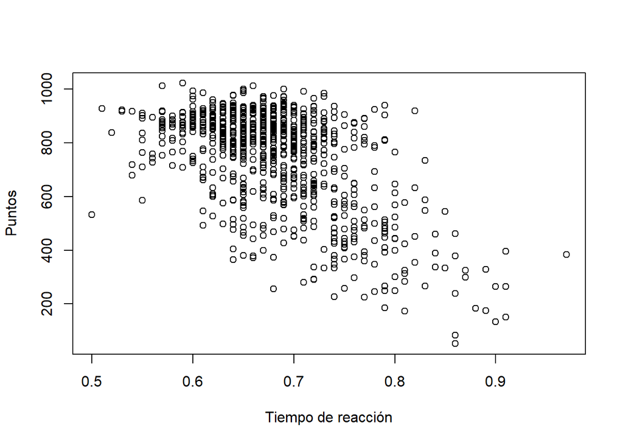

```r
plot(X,Y,xlab="Tiempo de reacción",ylab="Puntos")
```

```r
cov(X,Y)
```

```
## [1] -6.859023
```

A pesar de la confirmación, en este momento nos surge un problema, pues, la covarianza toma valores en todos los números reales, dependiendo de las magnitudes del tiempo de reacción y puntos, y de sus unidades . Por eso, calcularemos el coeficiente de correlación lineal, que se obtiene tipificando la covarianza, es decir, dividiendo la covarianza entre las desviaciones típicas muestrales (obteniendo un coeficiente entre -1 y 1)

```r
cor(X,Y)
```

```
## [1] -0.5573374
```

De manera adicional, podemos incluir histogramas marginales en cada eje del gráfico, para ello usamos las librerías `ggplot2` y `ggExtra`.

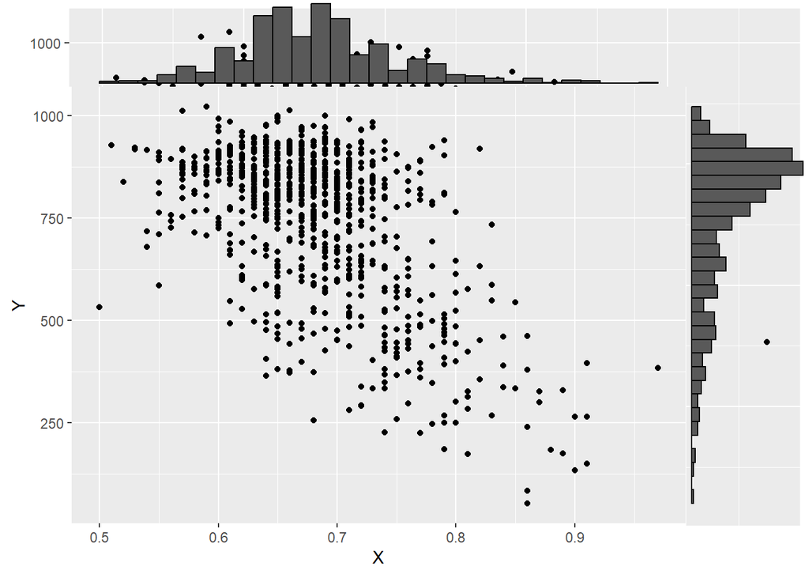

```r
datos<-data.frame(x=X,y=Y)

p<-ggplot(datos, aes(x = X, y = Y)) +
  geom_point()
#vemos la nube de puntos
print(p)
#Especificamos que se añadan histogramas en los márgenes
ggMarginal(p, type = "histogram")
```

Como hemos visto, si la relacion lineal es fuerte tiene sentido querer ajustar una recta a la nube de puntos. Es decir, considerar un modelo de regresion lineal simple.

La función que ajusta el modelo de regresión lineal simple en R es `lm`(con parametros B_0,B_1 y sigma^2), directamente hacemos un `summary` para que nos devuelva la información más importante, aunque realmente `lm` calcula muchas cosas: estimaciones, residuos, predicciones, etc.

```r
lm=lm(Y~X)
summary(lm)
```

```
##
## Call:
## lm(formula = Y ~ X)
##
## Residuals:
##    Min     1Q Median     3Q    Max
## -495.9  -88.7   22.7  109.2  391.1
##
## Coefficients:
##             Estimate Std. Error t value Pr(>|t|)
## (Intercept)  1809.05      55.43   32.64   <2e-16 ***
## X           -1562.32      80.84  -19.33   <2e-16 ***
## ---
## Signif. codes:  0 '***' 0.001 '**' 0.01 '*' 0.05 '.' 0.1 ' ' 1
##
## Residual standard error: 154.3 on 829 degrees of freedom
## Multiple R-squared:  0.3106, Adjusted R-squared:  0.3098
## F-statistic: 373.5 on 1 and 829 DF,  p-value: < 2.2e-16
```

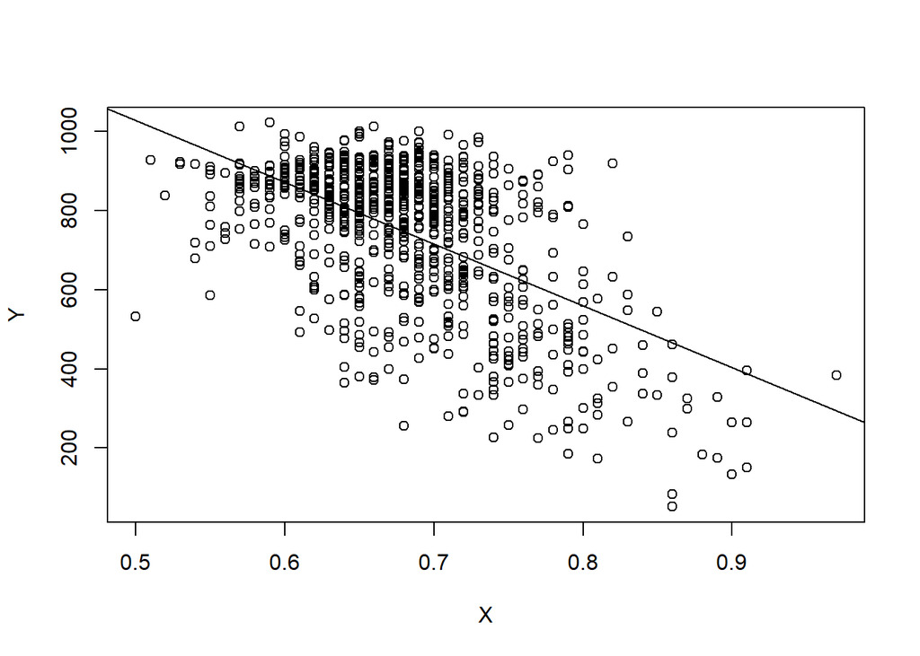

```r
#representamos
plot(X,Y)
#añadimos la recta de regresion
abline(lm)
```

Los coeficientes de la regresión estimados también están en el objeto donde hemos guardado el ajuste, en `lm`

```r
#generamos un vector con los coeficientes de la regresion
coeficientes=lm$coefficients
#comprobamos que es lo mismo que nos salía en el summary
coeficientes
```

```
## (Intercept)           X
##    1809.053   -1562.315
```

## Prueba 800m Libre femenino.

Veamos qué nadadores nadaron el 800 libre femenino:

```r
nadadoras800free<-nadadoresPruebas[nadadoresPruebas$distance==800 & nadadoresPruebas$gender=="F", ]

dim(nadadoras800free)
```

```
## [1] 51 24
```

Nos vamos a fijar en la final, para ello, filtramos otra vez los datos:

```r
nadadoras800free<-datos2015[datos2015$gender=="F" & datos2015$distance==800 & datos2015$round=="FIN", ]
```

#### Estudio sobre los parciales de la carrera.

Vamos a evaluar cómo fueron los parciales de las nadadoras, para ello hacemos el siguiente gráfico:

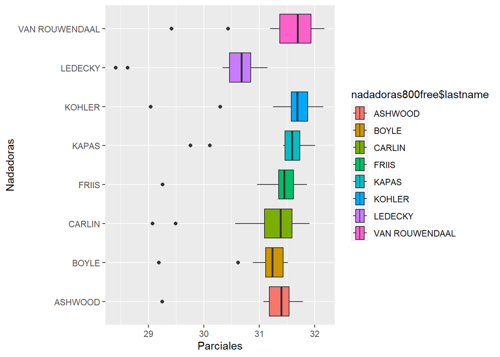

```r
ggplot(nadadoras800free, aes(y=nadadoras800free$lastname, x=nadadoras800free$splitswimtime, fill=nadadoras800free$lastname))+
  geom_boxplot()+
  labs(x="Parciales", y="Nadadoras")
```

De aquí podemos observar la media y los cuantiles de los parciales de las nadadoras. Observamos que casi todas tienen 1 o incluso 2 puntos atípicos, seguramente se deban al primer y último parcial de la prueba. Además, podemos observar que algunas nadadoras como Kapas y Friis, tuvieron una desviación muy pequeñita en sus parciales, es decir, fueron a un ritmo constante durante toda la prueba clavando sus parciales.

Vamos a observar, para cada nadador, los parciales realizados para ver si podemos conseguir algún patrón de tipo de carrera:

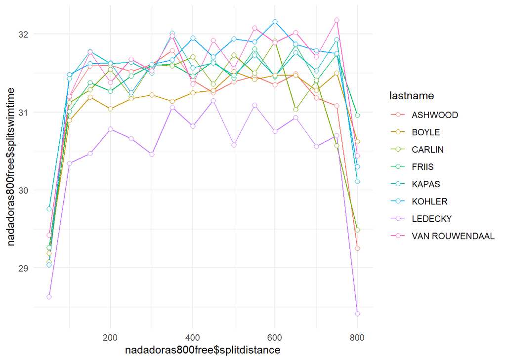

```r
ggplot(nadadoras800free, aes(x=nadadoras800free$splitdistance, y=nadadoras800free$splitswimtime, group = lastname, colour =lastname )) +
  geom_line()  +
  geom_point( size=2, shape=21, fill="white") +
  theme_minimal()
```

Observamos que todas nadan muy rápido tanto el primer parcial como el último. Además, vemos de manera clara como Ledecky parece que alterna un largo un poco más rapido y luego otro más lento durante toda su prueba. ¿Puede ser una estrategia de carrera? Lo veremos más adelante. También vemos alguna otra nadadora más que hace algo similar como Van Rouwendaal. Otras en cambio, intentan conservar el ritmo marcado desde el inicio y ser constantes. Carlin mete un cambio de ritmo muy drástico al paso de los 650m de 31s altos a 31s bajos y sigue luego bajando.

#### Visualización de la carrera.

Ahora, vamos a definir una tabla en la que nos va a importar el nombre, la suma total de tiempo al paso de cada parcial:

```r
nadadoras800free <- nadadoras800free %>%
  dplyr::select(lastname,firstname,gender,reactiontime,splitdistance,cumswimtime, swimtime)
```

Visualizamos la carrera:

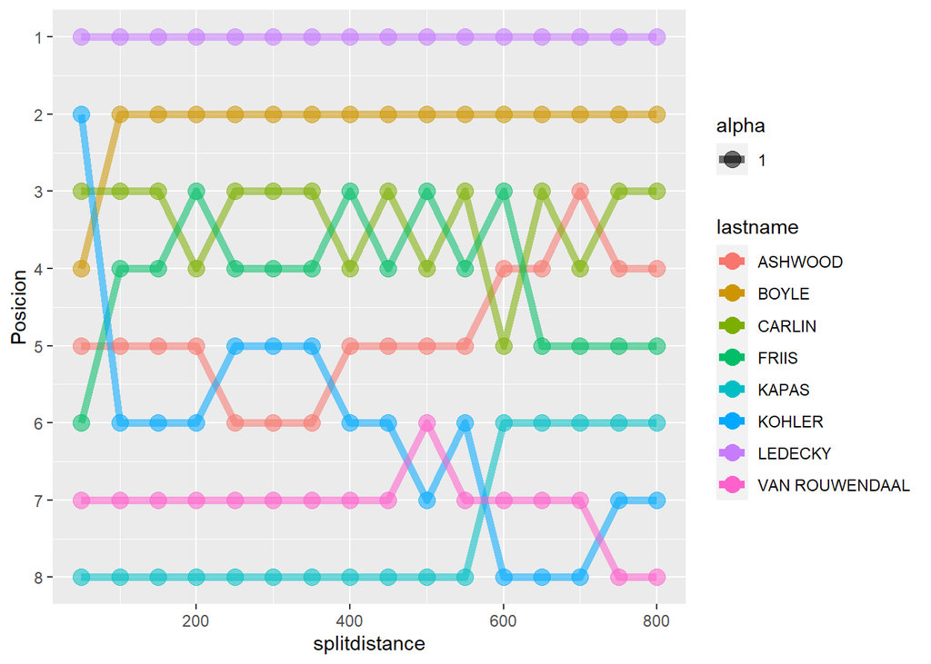

```r
# Ordenar los datos por tiempo
nadadoras800free <- nadadoras800free %>%
  arrange(splitdistance, cumswimtime)

# Crear un índice de posición
nadadoras800free <- nadadoras800free %>%
  group_by(splitdistance) %>%
  mutate(Posicion = rank(cumswimtime, ties.method = "first"))



ggplot(nadadoras800free, aes(x = splitdistance, y = Posicion, group = lastname)) +
  geom_line(aes(color = lastname, alpha = 1), size = 2) +
  geom_point(aes(color = lastname, alpha = 1), size = 4) +
  scale_y_reverse(breaks = 1:nrow(nadadoras800free))
```

# PCA’s

Realizaremos ahora el análisis de componentes principales del 800m libres femenino:

## PCA. 800M libres femenino

Lo primero que debemos hacer es cargar los datos:

```r
prueba800libresPreliminar<- datos2015[datos2015$distance==800 & datos2015$gender=="F" & datos2015$stroke=="FREE" & datos2015$round=="PRE", ]

prueba800libresPreliminar <- prueba800libresPreliminar %>%
    dplyr::select(lastname, reactiontime, splitdistance, splitswimtime, edad)
```

Bien, ahora, debemos encontrar la manera de crear una tabla en la que nos quedemos con el nombre, apellido y parciales.

```r
pruebawide <- prueba800libresPreliminar %>%
  pivot_wider(names_from = splitdistance,       # Los valores de 'Split' serán los nombres de las columnas
              values_from =splitswimtime)     # Los valores de 'Tiempo' llenarán las celdas
pruebawide
```

```
## # A tibble: 44 × 19
##    lastname   reactiontime  edad  `50` `100` `150` `200` `250` `300` `350` `400`
##    <chr>             <dbl> <dbl> <dbl> <dbl> <dbl> <dbl> <dbl> <dbl> <dbl> <dbl>
##  1 HOLOWCHAK          0.71    14  32.4  35.9  35.0  36.4  35.9  36.2  36.7  36.8
##  2 VAN DEN B…         0.79    19  31.6  33.9  34.1  34.2  33.7  33.9  34.2  33.9
##  3 ASHWOOD            0.78    22  29.2  31.4  31.8  31.9  31.9  32.0  31.9  31.7
##  4 NEALE              0.73    20  29.5  32.5  33.2  32.9  32.7  32.8  33.6  33.7
##  5 EVANS              0.79    18  30    32.3  33.0  32.8  33.0  32.9  33.2  33.6
##  6 GILL               0.9     16  31.2  34.5  34.6  34.6  34.6  35.0  35.1  35.2
##  7 KOBRICH            0.81    30  30.3  31.9  32.2  32.2  32.2  32.2  32.3  32.3
##  8 ZHANG              0.72    20  29.6  31.8  32.4  32.1  32.5  32.4  32.6  32.5
##  9 CAO                0.82    19  29.6  32.6  32.7  32.5  32.5  32.4  32.6  32.5
## 10 TE FLAN            0.84    20  30.4  34.3  33.8  34.9  34.8  35.4  35.0  36.1
## # ℹ 34 more rows
## # ℹ 8 more variables: `450` <dbl>, `500` <dbl>, `550` <dbl>, `600` <dbl>,
## #   `650` <dbl>, `700` <dbl>, `750` <dbl>, `800` <dbl>
```

```r
#omito los valores nulos:
pruebawide<- na.omit(pruebawide)
row.names(pruebawide) <- pruebawide$lastname # esto es para llamar a las filas con el nombre de los nadadores
```

Ahora que ya tenemos nuestra tabla hecha, vamos a hacer el PCA:

```r
prcomp(pruebawide[,-1], scale=T)
```

```
## Standard deviations (1, .., p=18):
##  [1] 3.89747634 1.04130246 0.77791355 0.73825364 0.50625249 0.31756324
##  [7] 0.26117066 0.21651865 0.16872466 0.15815858 0.10756232 0.09255060
## [13] 0.08565274 0.08227018 0.07435885 0.06567886 0.05874500 0.04421473
##
## Rotation (n x k) = (18 x 18):
##                      PC1           PC2          PC3         PC4         PC5
## reactiontime  0.06193838 -0.8548167721  0.390560844  0.32124873 -0.03857645
## edad         -0.14922291 -0.4272042870 -0.865816941 -0.01292133  0.19527371
## 50            0.21873835 -0.1852520188 -0.047501605 -0.54013522 -0.43636572
## 100           0.24304415 -0.0906112177  0.013301059 -0.32452317 -0.11528177
## 150           0.24266268 -0.1221686581  0.040018216 -0.30576570 -0.01078452
## 200           0.25220373 -0.0435807848 -0.047430110 -0.18342797  0.05149037
## 250           0.25150962 -0.0450643808  0.004591957 -0.16016883  0.14254777
## 300           0.25229932 -0.0067871667 -0.028203926 -0.09798486  0.20200703
```

[output cut: 67 more lines]

```r
summary(prcomp(pruebawide[,-1],scale=T))
```

```
## Importance of components:
##                           PC1     PC2     PC3     PC4     PC5    PC6     PC7
## Standard deviation     3.8975 1.04130 0.77791 0.73825 0.50625 0.3176 0.26117
## Proportion of Variance 0.8439 0.06024 0.03362 0.03028 0.01424 0.0056 0.00379
## Cumulative Proportion  0.8439 0.90415 0.93777 0.96804 0.98228 0.9879 0.99167
##                           PC8     PC9    PC10    PC11    PC12    PC13    PC14
## Standard deviation     0.2165 0.16872 0.15816 0.10756 0.09255 0.08565 0.08227
## Proportion of Variance 0.0026 0.00158 0.00139 0.00064 0.00048 0.00041 0.00038
## Cumulative Proportion  0.9943 0.99586 0.99725 0.99789 0.99837 0.99878 0.99915
##                           PC15    PC16    PC17    PC18
## Standard deviation     0.07436 0.06568 0.05874 0.04421
## Proportion of Variance 0.00031 0.00024 0.00019 0.00011
## Cumulative Proportion  0.99946 0.99970 0.99989 1.00000
```

Ahora, veamos cómo se ven los datos:

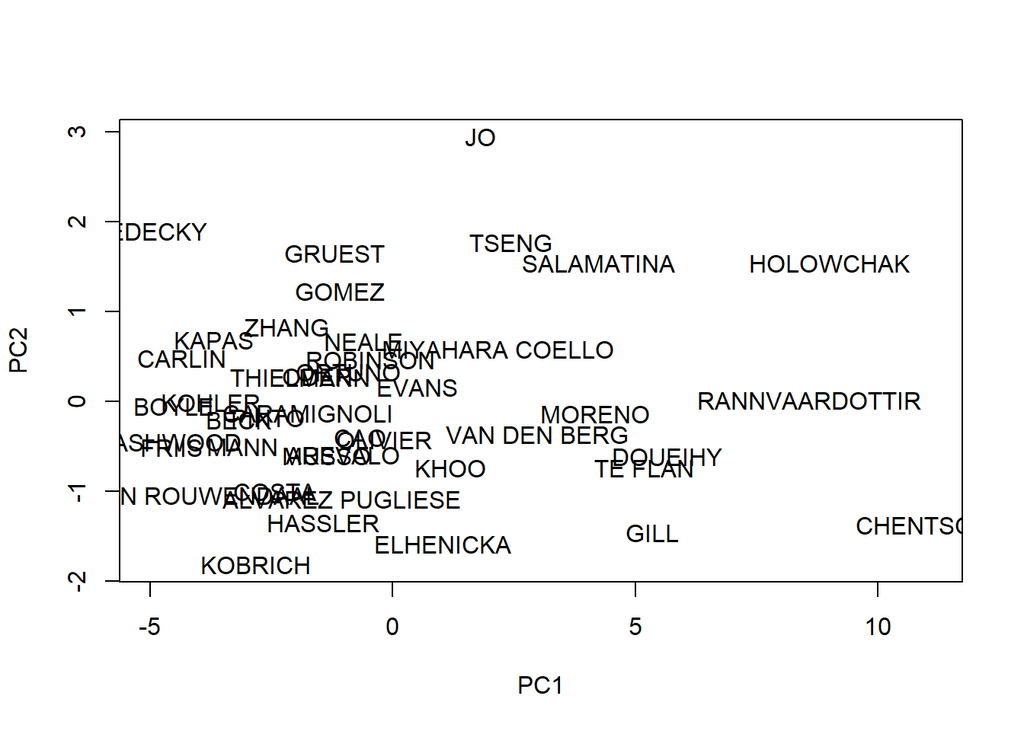

```r
plot(prcomp(pruebawide[,-1],scale=T)$x[,1:2], type="n")
text(prcomp(pruebawide[,-1],scale=T)$x[,1:2],rownames(pruebawide))
```

Si nos fijamos en la variable PC1, tenemos más a la izquierda a las nadadoras más rápidas en media en la prueba y a la derecha las más lentas.

Si nos fijamos en la variable PC2, más arriba tenemos a las nadadoras con MENOR tiempo de reacción y abajo las que tienen mayor tiempo de reacción, variando un poco también con la edad pero no siendo tan significativa.

Veamos cómo queda el biplot:

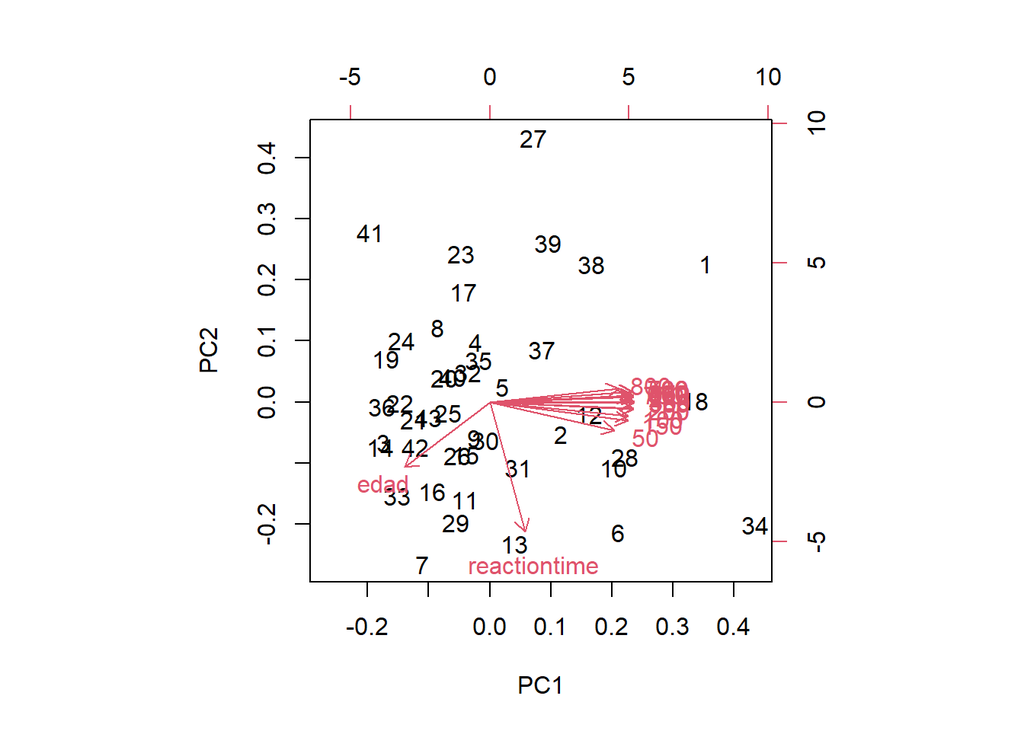

```r
biplot(prcomp(pruebawide[,-1],scale=T))
```

## PCA 100m mariposa femenino

```r
# Filtro de pruebas de 100m mariposa femenino
prueba100MariposaFem <- datos2015[datos2015$distance==100 & datos2015$gender=="F" & datos2015$stroke=="FLY" & datos2015$round =="PRE",]

# Selección de columnas relevantes
prueba100MariposaFem <- prueba100MariposaFem %>% dplyr::select(lastname, reactiontime, splitdistance, splitswimtime)
```

```r
prueba <- prueba100MariposaFem %>%
  pivot_wider(names_from = splitdistance,       # Los valores de 'Split' serán los nombres de las columnas
              values_from =splitswimtime)     # Los valores de 'Tiempo' llenarán las celdas

#Eliminamos duplicados y NA de la columna 'lastname'
prueba <- prueba[!duplicated(prueba$lastname) & !is.na(prueba$lastname), ]

prueba <- as.data.frame(prueba)

# Asignar los nombres de fila como el apellido del nadador
row.names(prueba) <- prueba$lastname

#Eliminamos filas con NA restantes
prueba <- na.omit(prueba)
```

Con todo esto, estamos preparados para realizar el PCA:

```r
#Realizamos el PCA
pca_100mariposafemenino <- prcomp(prueba[,-1], scale=T)

# Resultados del PCA
summary(pca_100mariposafemenino)
```

```
## Importance of components:
##                           PC1    PC2     PC3
## Standard deviation     1.4922 0.8357 0.27348
## Proportion of Variance 0.7423 0.2328 0.02493
## Cumulative Proportion  0.7423 0.9751 1.00000
```

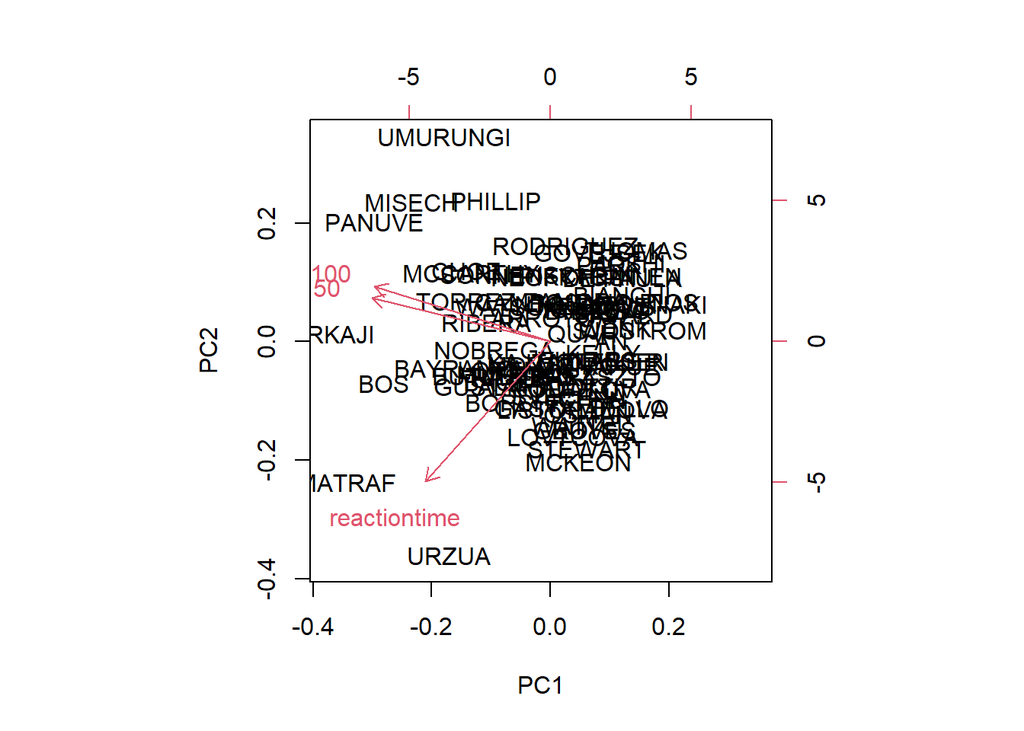

```r
#Visualización del PCA
biplot(pca_100mariposafemenino)
```

Obtenemos que la componente 1 (PC1) explica un 74,23% de las prueba y la 2 un 23,28%. También tenemos una gráfica del PCA realizado.

Cargamos los datos:

```r
prueba50MariposaMasc<- datos2015[datos2015$distance==50 & datos2015$gender=="M" & datos2015$stroke=="FLY", ]

prueba50MariposaMasc <- prueba50MariposaMasc %>%
    dplyr::select(lastname, reactiontime, splitdistance, splitswimtime, edad, swimtime)
```

De manera análoga, creamos una tabla en la que nos quedamos con el nombre, apellido y parciales

```r
pruebita <- prueba50MariposaMasc %>%
  pivot_wider(names_from = splitdistance,       # Los valores de 'Split' serán los nombres de las columnas
              values_from =splitswimtime)     # Los valores de 'Tiempo' llenarán las celdas
pruebita
```

```
## # A tibble: 106 × 5
##    lastname    reactiontime  edad swimtime  `50`
##    <chr>              <dbl> <dbl>    <dbl> <dbl>
##  1 MITCHELL            0.68    15     27.7  27.7
##  2 GRASSI              0.63    18     24.0  24.0
##  3 MKHITARYAN          0.69    19     26.2  26.2
##  4 HADLER              0.69    21     23.8  23.8
##  5 BURROWS             0.63    26     24.2  24.2
##  6 IRAKOZE             0.8     18     30.4  30.4
##  7 HEERSBRANDT         0.63    25     23.6  23.6
##  8 HEERSBRANDT         0.61    25     23.3  23.3
##  9 BESSAN              0.77    36     31.5  31.5
## 10 TSURKIN             0.66    24     23.5  23.5
## # ℹ 96 more rows
```

```r
#omito los valores nulos:
pruebita<- na.omit(pruebawide)
```

Hacemos el PCA:

```r
prcomp(pruebita[,-1], scale=T)
```

```
## Standard deviations (1, .., p=18):
##  [1] 3.89747634 1.04130246 0.77791355 0.73825364 0.50625249 0.31756324
##  [7] 0.26117066 0.21651865 0.16872466 0.15815858 0.10756232 0.09255060
## [13] 0.08565274 0.08227018 0.07435885 0.06567886 0.05874500 0.04421473
##
## Rotation (n x k) = (18 x 18):
##                      PC1           PC2          PC3         PC4         PC5
## reactiontime  0.06193838 -0.8548167721  0.390560844  0.32124873 -0.03857645
## edad         -0.14922291 -0.4272042870 -0.865816941 -0.01292133  0.19527371
## 50            0.21873835 -0.1852520188 -0.047501605 -0.54013522 -0.43636572
## 100           0.24304415 -0.0906112177  0.013301059 -0.32452317 -0.11528177
## 150           0.24266268 -0.1221686581  0.040018216 -0.30576570 -0.01078452
## 200           0.25220373 -0.0435807848 -0.047430110 -0.18342797  0.05149037
## 250           0.25150962 -0.0450643808  0.004591957 -0.16016883  0.14254777
## 300           0.25229932 -0.0067871667 -0.028203926 -0.09798486  0.20200703
```

[output cut: 67 more lines]

```r
summary(prcomp(pruebita[,-1],scale=T))
```

```
## Importance of components:
##                           PC1     PC2     PC3     PC4     PC5    PC6     PC7
## Standard deviation     3.8975 1.04130 0.77791 0.73825 0.50625 0.3176 0.26117
## Proportion of Variance 0.8439 0.06024 0.03362 0.03028 0.01424 0.0056 0.00379
## Cumulative Proportion  0.8439 0.90415 0.93777 0.96804 0.98228 0.9879 0.99167
##                           PC8     PC9    PC10    PC11    PC12    PC13    PC14
## Standard deviation     0.2165 0.16872 0.15816 0.10756 0.09255 0.08565 0.08227
## Proportion of Variance 0.0026 0.00158 0.00139 0.00064 0.00048 0.00041 0.00038
## Cumulative Proportion  0.9943 0.99586 0.99725 0.99789 0.99837 0.99878 0.99915
##                           PC15    PC16    PC17    PC18
## Standard deviation     0.07436 0.06568 0.05874 0.04421
## Proportion of Variance 0.00031 0.00024 0.00019 0.00011
## Cumulative Proportion  0.99946 0.99970 0.99989 1.00000
```

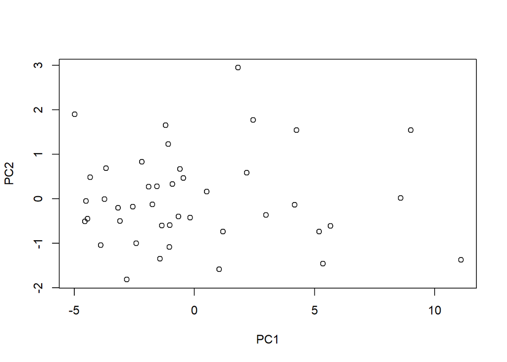

```r
plot(prcomp(pruebita[,-1],scale=T)$x[,1:2])
```

# Tareas por hacer e ideas surgidas:

- Ver quién “rindió” mejor en los mundiales entre hombres y mujeres y respecto a los puntos.
- Sacar conclusiones del PCA.
- Hacer el clustering.
- Hacer un pca del 100 braza masculino y clustering
- Hacer un pca del 50 mariposa masculino y clustering(cada uno que haga un PCAhecho) -EDA el grafico de paises en vez de por numero de personas, el numero de puntos

# Clusters

```r
kmedias=kmeans(prcomp(pruebawide[,-1],scale=T)$x[,1:2], centers=2, nstar=25)

kmedias
```

```
## K-means clustering with 2 clusters of sizes 31, 12
##
## Cluster means:
##        PC1        PC2
## 1 -2.02373 -0.1199687
## 2  5.22797  0.3099190
##
## Clustering vector:
##  [1] 2 2 1 1 1 2 1 1 1 2 1 2 1 1 1 1 1 2 1 1 1 1 1 1 1 1 2 2 1 1 1 1 1 2 1 1 2 2
## [39] 2 1 1 1 1
##
## Within cluster sum of squares by cluster:
## [1] 110.1361 116.8596
##  (between_SS / total_SS =  66.8 %)
##
## Available components:
##
## [1] "cluster"      "centers"      "totss"        "withinss"     "tot.withinss"
## [6] "betweenss"    "size"         "iter"         "ifault"
```